# **MATH 3190 Homework 5**

Due February 26, 2026  
Focus: Boostrapping from Notes 5 and Notes 7 Part 1  
Total Points: 90 + 10 (Self-Critique Comment and Uploading to GitHub) = 100

Note that your homework should be completed in Quarto. You can just add your answers and code to this document in the appropriate part. The file should be rendered as an html document or pdf document (html is quicker to render and you will need an installation of LaTeX to render as a pdf). You will “turn in” this homework by uploading the files, the .qmd and output file, to your GitHub `Math_3190_Assignment` repository in the `Homework/Homework_5` directory. Make sure all supporting files (if there are any) are in this directory as well. You should use `git` and `Unix` commands in a terminal for this (i.e. don’t manually upload files to GitHub). In addition, you will submit just your html or pdf file on Canvas to unlock the solutions.

Don’t forget to also put a self-critique comment on Canvas indicating what you did correctly and incorrectly and include any questions you may have about the assignment after submitting the assignment and thoroughly looking through the solutions.

Also, there is a package I created with many functions and data files we will be using for the remainder of this class. You can install this package instead of downloading and reading in the data files. To download the package, do the following in **R**:

1. Install the remotes or the `devtools` package using either `install.packages("remotes")` or `install.packages("devtools")`.
2. Load the package: `library(remotes)` or `library(devtools)`.
3. Install the course package: `install_github("rbrown53/math3190package")`. If it asks you if you want to update packages, you can select that you do.
4. Now, you will simply have to load the package (which will also load the `tidyverse`) for each homework assignment: `library(math3190package)`.

# Problem 1 (35 points)

We first covered bootstrapping in Notes 5, but we returned to it here. Let’s do a problem on bootstrapping that takes ideas from Notes 5 and Notes 7.

The amount of money spent on health care is an important issue for workers because many companies provide health insurance that only partial covers many medical procedures. The director of employee benefits at a midsize company wants to determine the amount spent on health care by the typical hourly worker in the company. A random sample of 25 workers is selected and the amounts they spent on their family’s health care needs during the past year can be found in the `healthcare` tibble in the `math3190package`.

```r
library('math3190package')
head(healthcare)
```

```
# A tibble: 6 × 1
  amount
   <int>
1    400
2    345
3    248
4   1290
5    398
6    218
```

### Part a (4 points)

Graph the data using both a boxplot and normal quantile plot (QQ plot) and use these to assess whether the population has a normal distribution.

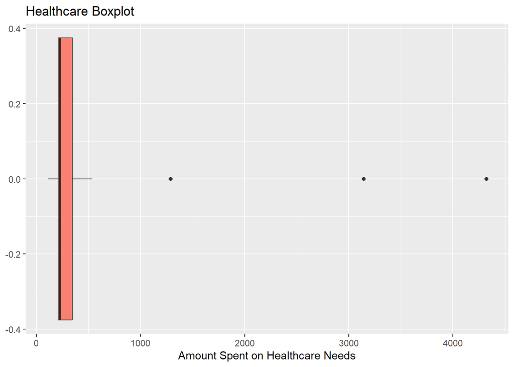

```r
# Boxplot
ggplot(data = healthcare, aes(x = amount)) +
  geom_boxplot(fill = 'Salmon') +
  labs(title = "Healthcare Boxplot", x = "Amount Spent on Healthcare Needs")
```

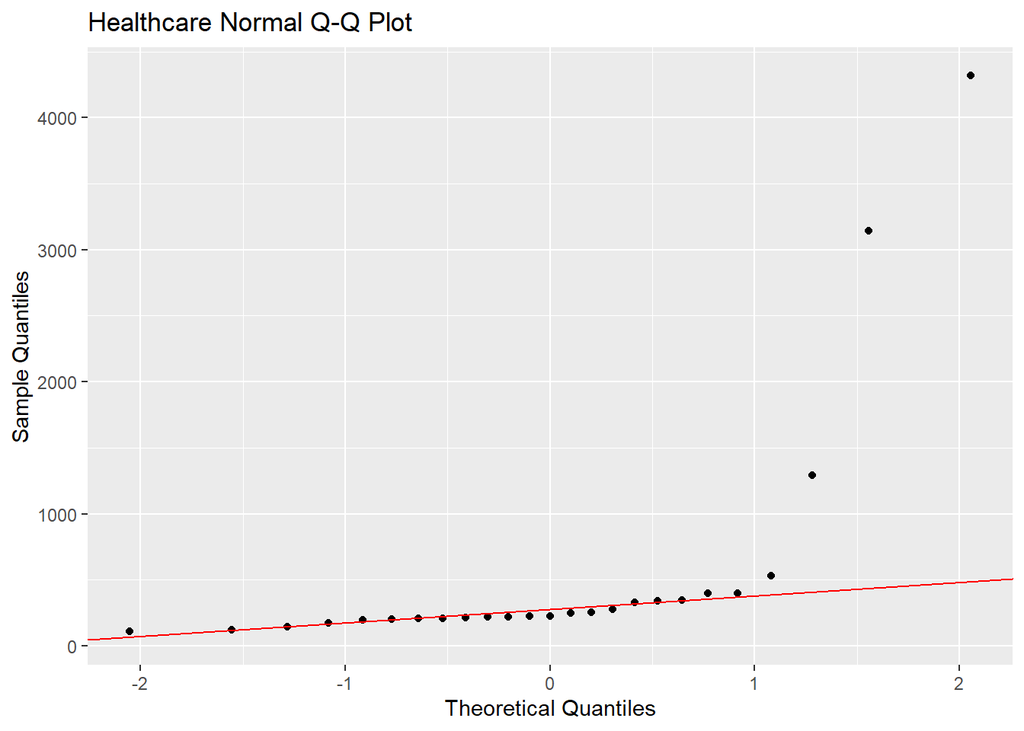

```r
# QQ Plot
ggplot(data = healthcare, aes(sample = amount)) +
  stat_qq() +
  stat_qq_line(color = "red") +
  labs(title = "Healthcare Normal Q-Q Plot",
       x = "Theoretical Quantiles",
       y = "Sample Quantiles")
```

There is a long tail right tail on the data. This mostly involves the last 3 entries. This means the data does not follow a normal distribution.

### Part b (4 points)

Construct a 95% confidence interval for the mean cost per household using a t-interval. You can use the `t.test()` function for this. Interpret this confidence interval in context of the problem and comment on whether the t-procedure is appropriate to use here.

```r
t.test(healthcare)
```

```
    One Sample t-test

data:  healthcare
t = 2.8884, df = 24, p-value = 0.008078
alternative hypothesis: true mean is not equal to 0
95 percent confidence interval:
 163.5954 982.6446
sample estimates:
mean of x
   573.12
```

We are 95% confident that the true mean of the healthcare cost per household is between $163.60 and $982.64. A t-test is not appropriate since the data does not follow a normal distribution.

### Part c (7 points)

Now let’s use bootstrapping to estimate a 95% interval for the mean.

First, write a loop yourself that will do this. In the loop, you’ll need to sample from your data set with replacement, take the mean of that sample, and then store those means. Have the loop do this 10,000 times. Then you can obtain a 95% interval by using the quantile function in **R**. Specifically, you can type `quantile(means_vector, c(0.025, 0.975))` (if you call your vector `means_vector`) to get a 95% interval based on the percentile method.

```r
# Setup
set.seed(2026)
n <- length(healthcare$amount)
means_vector <- numeric(10000) # Creates a vector with 10,000 entries
amount <- healthcare$amount

for(i in 1:10000){

  # sample with replacement
  boot_sample <- sample(amount, n, replace = TRUE)

  # store the mean
  means_vector[i] <- mean(boot_sample)
}

# 95% percentile interval
quantile(means_vector, c(0.025, 0.975))
```

```
    2.5%    97.5%
 259.112 1003.602
```

### Part d (5 points)

Now use the `bootstrapping()` function in the `math3190package` library to obtain a bootstrap object using 10,000 samples. Then use the `boot_ci()` function to obtain the 95% intervals. Report the Percentile interval and BCa interval. Compare your interval from part (c) to the Percentile interval computed here. They should be similar.

```r
set.seed(2026)

boot_mean <- function(x, i){mean(x[i])}
boot_out <- bootstrapping(amount, boot_mean, R = 10000)
bootci_out <- boot_ci(boot_out)
bootci_out
```

```
BOOTSTRAP CONFIDENCE INTERVAL CALCULATIONS
Based on 10000 bootstrap replicates

# A tibble: 4 × 4
  interval_type conf_level lower upper
  <chr>              <dbl> <dbl> <dbl>
1 normal              0.95  199.  953.
2 basic               0.95  150.  885.
3 percent             0.95  261.  997.
4 bca                 0.95  306. 1235.

Calculations and Intervals on Original Scale
Some BCa intervals may be unstable
```

### Part e (3 points)

Write a sentence or two comparing the intervals you obtained in parts (c) and (d) to the t-interval you constructed in part (b).

**The interval in part d is a bit narrower than the interval in part b. Part d’s interval is shifted to the right compared to the other 2.**

### Part g (4 points)

Use the `boostrapping()` function with at least 10,000 samples to obtain a 95% confidence interval based on BCa for the median.

```r
set.seed(2026)

boot_median <- function(x, i){median(x[i])}
boot_out <- bootstrapping(amount, boot_median, R = 10000)
bootci_out <- boot_ci(boot_out)
bootci_out
```

```
BOOTSTRAP CONFIDENCE INTERVAL CALCULATIONS
Based on 10000 bootstrap replicates

# A tibble: 4 × 4
  interval_type conf_level lower upper
  <chr>              <dbl> <dbl> <dbl>
1 normal              0.95  146.  272.
2 basic               0.95  108   242
3 percent             0.95  208   342
4 bca                 0.95  208   326

Calculations and Intervals on Original Scale
Some BCa intervals may be unstable
```

### Part h (5 points)

The IQR is a measure of spread commonly used with the median. Construct a 95% confidence interval based on BCa for the IQR using the `bootstrapping()` function with at least 10,000 samples and interpret the interval. Also plot the output of the `bootstrapping()` function and comment on whether the distribution looks close to normal.

```r
set.seed(2026)

boot_iqr <- function(x, i){
  IQR(x[i])
}

boot_out_iqr <- bootstrapping(amount, boot_iqr, R = 10000)

bootci_out_iqr <- boot_ci(boot_out_iqr)
bootci_out_iqr
```

```
BOOTSTRAP CONFIDENCE INTERVAL CALCULATIONS
Based on 10000 bootstrap replicates

# A tibble: 4 × 4
  interval_type conf_level lower upper
  <chr>              <dbl> <dbl> <dbl>
1 normal              0.95 -312.  499.
2 basic               0.95  -83   229
3 percent             0.95   47   359
4 bca                 0.95   46   330

Calculations and Intervals on Original Scale
Some BCa intervals may be unstable
```

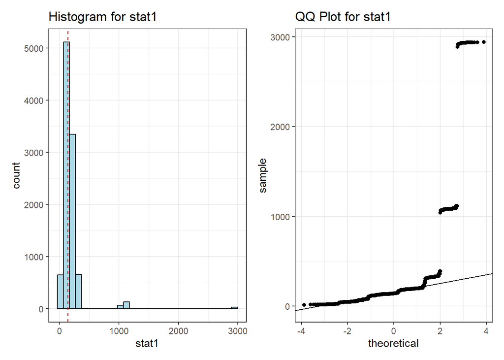

```r
plot(boot_out_iqr)
```

It’s still not normal.

### Part i (3 points)

In all of these bootstraps, what did we have to assume about the population in order for these intervals to be valid?

**We assume that the sample comes from a large population and that we are using simple random sampling from the population.**

# Problem 2 (55 points)

Concrete is the most important material in civil engineering. The concrete compressive strength is an important attribute of the concrete and our goal is to predict the concrete compressive strength (in MPa) from the following variables:

- Cement (in $\text{kg}/\text{m}^3$)
- Blast furnace slag (in $\text{kg}/\text{m}^3$)
- Fly ash (in $\text{kg}/\text{m}^3$)
- Water (in $\text{kg}/\text{m}^3$)
- Superplasticizer (in $\text{kg}/\text{m}^3$)
- Coarse aggregate (in $\text{kg}/\text{m}^3$)
- Fine aggregate (in $\text{kg}/\text{m}^3$)
- Age of concrete (in days)

This dataset came from the [UCI ML Repository](https://archive.ics.uci.edu/dataset/165/concrete+compressive+strength) and can be found on the Math3190_Sp26 GitHub page along with a Readme file and in the `Concrete_Data` tibble in the `math3190package` **R** library.

### Part a (2 points)

Change the names of the variables in `Concrete_Data` so they are shorter yet still descriptive. Name this something other than `Concrete_Data` so you don’t overwrite it.

```r
concrete_tib <- Concrete_Data %>%
  rename(
    cement = `Cement (component 1)(kg in a m^3 mixture)`,
    blast_slag = `Blast Furnace Slag (component 2)(kg in a m^3 mixture)`,
    fly_ash = `Fly Ash (component 3)(kg in a m^3 mixture)`,
    water = `Water  (component 4)(kg in a m^3 mixture)`,
    superplasticizer = `Superplasticizer (component 5)(kg in a m^3 mixture)`,
    coarse_aggregate = `Coarse Aggregate  (component 6)(kg in a m^3 mixture)`,
    fine_aggregate = `Fine Aggregate (component 7)(kg in a m^3 mixture)`,
    age = `Age (day)`,
    compressive_strength = `Concrete compressive strength(MPa, megapascals)`)
    names(concrete_tib)
```

```
[1] "cement"               "blast_slag"           "fly_ash"
[4] "water"                "superplasticizer"     "coarse_aggregate"
[7] "fine_aggregate"       "age"                  "compressive_strength"
```

### Part b (5 points)

In the `GGally` library is the function `ggpairs()`, which makes a nice scatterplot matrix in the `ggplot2` style. `GGally` should have already been installed when you installed `math3190package`, so you will just need to load it. Using `ggpairs()`, Create this scatterplot matrix for all of the variables in the dataset (they should all be plotted together in one plot).

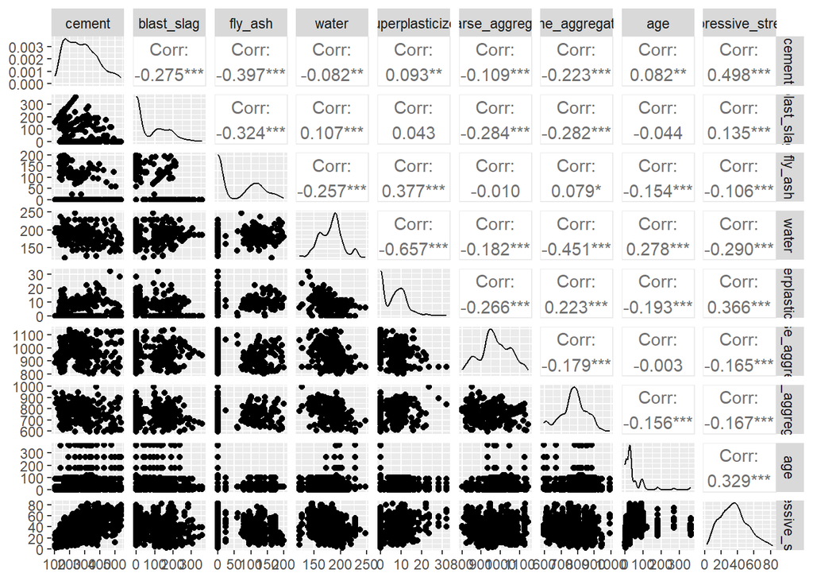

```r
library(GGally)
ggpairs(concrete_tib)
```

Comment on the scatterplot matrix. Which variables seem to have a (at least somewhat) linear relationship with compressive strength?

**Some variables appear to be skewed to the right. Age, superplasticizer, and cement all have moderate to weak correlation with compressive strength.**

### Part c (3 points)

Fit a linear model (with the `lm()` function) predicting compressive strength using all other variables. After you’ve done that, interpret the slope of the water variable in the context of the problem and answer whether it is considered a significant variable in the model.

```r
lm_concrete <- lm(compressive_strength ~ ., data = concrete_tib)
summary(lm_concrete)
```

```
Call:
lm(formula = compressive_strength ~ ., data = concrete_tib)

Residuals:
    Min      1Q  Median      3Q     Max
-28.653  -6.303   0.704   6.562  34.446

Coefficients:
                   Estimate Std. Error t value Pr(>|t|)
(Intercept)      -23.163756  26.588421  -0.871 0.383851
cement             0.119785   0.008489  14.110  < 2e-16 ***
blast_slag         0.103847   0.010136  10.245  < 2e-16 ***
fly_ash            0.087943   0.012585   6.988 5.03e-12 ***
water             -0.150298   0.040179  -3.741 0.000194 ***
superplasticizer   0.290687   0.093460   3.110 0.001921 **
coarse_aggregate   0.018030   0.009394   1.919 0.055227 .
fine_aggregate     0.020154   0.010703   1.883 0.059968 .
age                0.114226   0.005427  21.046  < 2e-16 ***
---
Signif. codes:  0 '***' 0.001 '**' 0.01 '*' 0.05 '.' 0.1 ' ' 1

Residual standard error: 10.4 on 1021 degrees of freedom
Multiple R-squared:  0.6155,    Adjusted R-squared:  0.6125
F-statistic: 204.3 on 8 and 1021 DF,  p-value: < 2.2e-16
```

**Compressive strength decreases by 0.150 units for every 1 unit increase of water. Holding all else constant.**

### Part d (6 points)

Using `ggplot()`, make a QQ plot of the raw residuals (obtained using the `residuals()` function). Include the QQ line as well. Comment on whether the residuals appear to be approximately normal.

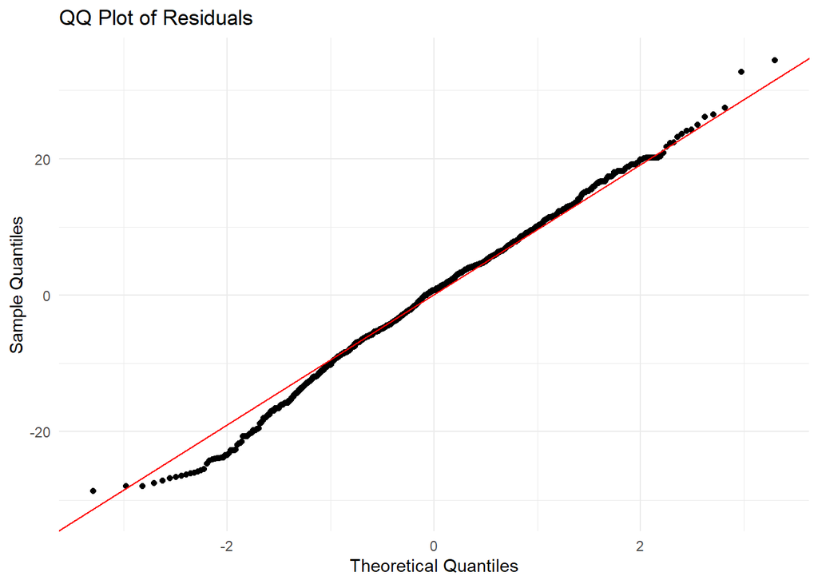

```r
resid_concrete <- tibble(resid_concrete = residuals(lm_concrete))

ggplot(data = resid_concrete, aes(sample = resid_concrete)) +
  stat_qq() +
  stat_qq_line(color = "red") +
  labs(title = "QQ Plot of Residuals", x = "Theoretical Quantiles", y = "Sample Quantiles") +
  theme_minimal()
```

Using `ggplot()`, make a plot of the jackknife residuals (obtained using the `rstudent()` function) on the y-axis and the fitted values of the model on the x-axis. Comment on whether this residual plot looks good. If it does not, indicate what the problem(s) is (are).

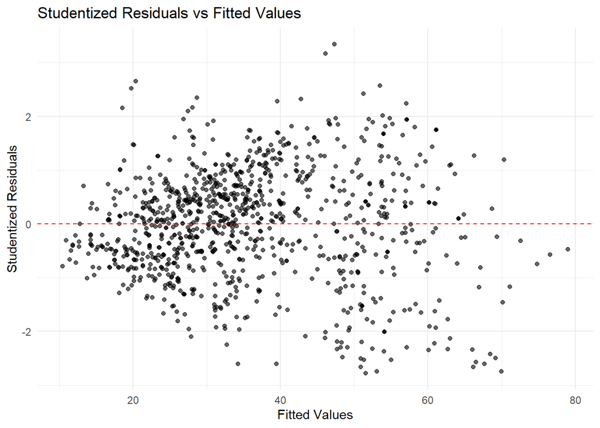

```r
# Studentized residuals
stud_resid <- rstudent(lm_concrete)

# Fitted values
fitted_vals <- fitted(lm_concrete)

# Tibble
resid_df <- tibble(
  fitted = fitted_vals,
  stud_resid = stud_resid
)

ggplot(resid_df, aes(x = fitted, y = stud_resid)) +
  geom_point(alpha = 0.6) +
  geom_hline(yintercept = 0, linetype = "dashed", color = "red") +
  labs(
    title = "Studentized Residuals vs Fitted Values",
    x = "Fitted Values",
    y = "Studentized Residuals"
  ) +
  theme_minimal()
```

### Part e (6 points)

Since the residual plots do not look good, let’s try to use weighted least squares. Following the code on page 118 and 119 of Notes 7, create a vector of weights and then fit a new model using weighted least squares.

```r
# Compute weights
w <- 1 / (fitted_vals^2)

# Weighted least squares model
lm_concrete_w <- lm(compressive_strength ~ ., data = concrete_tib, weights = w)

# View summary
summary(lm_concrete_w)
```

```
Call:
lm(formula = compressive_strength ~ ., data = concrete_tib, weights = w)

Weighted Residuals:
     Min       1Q   Median       3Q      Max
-0.83440 -0.19587  0.01665  0.19435  1.27210

Coefficients:
                   Estimate Std. Error t value Pr(>|t|)
(Intercept)      -36.615221  23.634523  -1.549   0.1216
cement             0.126394   0.007671  16.476  < 2e-16 ***
blast_slag         0.103943   0.008891  11.691  < 2e-16 ***
fly_ash            0.079363   0.010791   7.355 3.92e-13 ***
water             -0.095789   0.035321  -2.712   0.0068 **
superplasticizer   0.479987   0.092568   5.185 2.60e-07 ***
coarse_aggregate   0.017626   0.008265   2.132   0.0332 *
fine_aggregate     0.019331   0.009499   2.035   0.0421 *
age                0.165691   0.006607  25.079  < 2e-16 ***
---
Signif. codes:  0 '***' 0.001 '**' 0.01 '*' 0.05 '.' 0.1 ' ' 1

Residual standard error: 0.2865 on 1021 degrees of freedom
Multiple R-squared:  0.6874,    Adjusted R-squared:  0.685
F-statistic: 280.7 on 8 and 1021 DF,  p-value: < 2.2e-16
```

### Part f (5 points)

Using `ggplot()`, make a plot of the jackknife residuals (obtained using the `rstudent()` function) on the y-axis and the fitted values of the weighted model on the x-axis. Comment on whether this residual plot looks good and whether this plot looks better than the residual plot in part d.

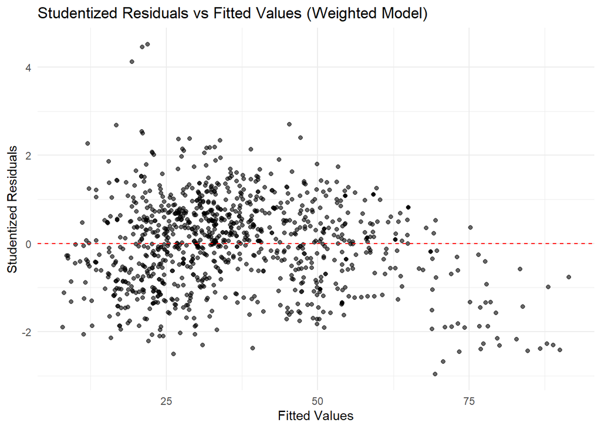

```r
# Studentized residuals for weighted model
stud_resid_w <- rstudent(lm_concrete_w)

# Fitted values for weighted model
fitted_vals_w <- fitted(lm_concrete_w)

# Combine into a tibble
resid_df_w <- tibble(
  fitted = fitted_vals_w,
  stud_resid = stud_resid_w
)

ggplot(resid_df_w, aes(x = fitted, y = stud_resid)) +
  geom_point(alpha = 0.6) +
  geom_hline(yintercept = 0, linetype = "dashed", color = "red") +
  labs(
    title = "Studentized Residuals vs Fitted Values (Weighted Model)",
    x = "Fitted Values",
    y = "Studentized Residuals"
  ) +
  theme_minimal()
```

**I would say it is about sixes. This one has less fanning, but it looks like the dots drop below the line on the right side.**

### Part f (8 points)

Using the unweighted model from part c and the weighted model from part e, find and report both a confidence interval for the mean compressive strength and a prediction interval for the specific compressive strength for concrete that has a cement value of 300, a blast furnace slag of 90, a fly ash of 50, a water value of 200, a superplasticizer of 2.5, a coarse aggregate of 900, a fine aggregate of 600, and an age of 300 days. You can use the `predict()` function here and remember that you will need to find the specific weight for the given predictor variable values for the weighted intervals. You can follow along with the code used on page 121 of Notes 7.

```r
# Specific Compressive Strength
new_obs <- tibble(
  cement = 300, blast_slag = 90, fly_ash = 50, water = 200,
  superplasticizer = 2.5, coarse_aggregate = 900, fine_aggregate = 600, age = 300
)

# Unweighted Intervals (Standard lm from Part c)
unweighted_conf <- predict(lm_concrete, newdata = new_obs, interval = "confidence")
unweighted_pred <- predict(lm_concrete, newdata = new_obs, interval = "prediction")

# Model the variance for the Weighted Intervals
abs_resids <- abs(residuals(lm_concrete))
fitted_vals <- fitted(lm_concrete)
error_model <- lm(abs_resids ~ fitted_vals)

# Find the weight for the new observation
new_fit_val <- predict(lm_concrete, newdata = new_obs)
pred_abs_resid <- predict(error_model, newdata = data.frame(fitted_vals = new_fit_val))
new_weight <- 1 / (pred_abs_resid^2)

# Calculate Weighted Intervals using the new weight
weighted_conf <- predict(lm_concrete_w, newdata = new_obs,
                         interval = "confidence", weights = new_weight)
weighted_pred <- predict(lm_concrete_w, newdata = new_obs,
                         interval = "prediction", weights = new_weight)

# Combine into a single table for comparison
results_matrix <- rbind(unweighted_conf, unweighted_pred, weighted_conf, weighted_pred)
rownames(results_matrix) <- c("OLS Confidence", "OLS Prediction", "WLS Confidence", "WLS Prediction")
print(results_matrix)
```

```
                    fit      lwr      upr
OLS Confidence 59.76989 55.66444 63.87534
OLS Prediction 59.76989 38.95351 80.58627
WLS Confidence 73.83733 69.34833 78.32633
WLS Prediction 73.83733 65.77243 81.90222
```

### Part g (10 points)

Write a function called `predict_weighted` that takes three inputs: the **unweighted** model, a data frame containing information about the value(s) of the predictor variables we are using to predict, and the interval type (either “confidence” or “prediction”). This function should return the predicted value and the interval bounds for the specified interval type for weighted least squares. So, this function should compute the weights, obtain the weighted least squares model, find the specific weight for the new value, and then get the prediction and the interval. This function should work for any linear model (made with the `lm()` function) you give it, not just for this exact situation of this problem. So, you should not reference any data sets or variables specific to this concrete problem in the function.

```r
predict_weighted <- function(unweighted_model, newdata, interval_type) {
  # Extract residuals and fitted values from the original model
  abs_resids <- abs(residuals(unweighted_model))
  fitted_vals <- fitted(unweighted_model)

  # Fit the error model to predict the variance (absolute residuals)
  error_model <- lm(abs_resids ~ fitted_vals)

  # Weights
  weights_vector <- 1 / (predict(error_model)^2)

  # Refit the original model using Weighted Least Squares
  wls_model <- update(unweighted_model, weights = weights_vector)

  # Calculate the specific weight
  new_fit_unweighted <- predict(unweighted_model, newdata = newdata)
  pred_abs_resid_new <- predict(error_model, newdata = data.frame(fitted_vals = new_fit_unweighted))
  weight_new <- 1 / (pred_abs_resid_new^2)

  # Generate the final prediction and interval
  prediction <- predict(wls_model,
                        newdata = newdata,
                        interval = interval_type,
                        weights = weight_new)

  return(prediction)
}
```

Test this new function for the confidence and prediction intervals you made in part f.

```r
# Test for Confidence Interval
test_conf <- predict_weighted(lm_concrete, new_obs, "confidence")

# Test for Prediction Interval
test_pred <- predict_weighted(lm_concrete, new_obs, "prediction")

# Display the results
test_results <- rbind(
  "Function WLS Conf" = test_conf,
  "Function WLS Pred" = test_pred
)

print(test_results)
```

```
       fit      lwr      upr
1 68.49046 64.15589 72.82503
1 68.49046 39.91450 97.06641
```

### Part h (5 points)

In this problem, based on the residual plots in part d, we found you the errors do not have constant variance. Another remedial measure for models with non-constant variance (heteroskedasticity) is to bootstrap the cases.

Using the `boostrapping()` function in `math3190package`, run a bootstrap of the cases for at least 5,000 bootstrap samples on the model coefficients. Note that an unweighted model should be fit when bootstrapping.

```r
boot_coefs <- function(data, i) {
  # Refit the model on the resampled indices 'i'
  boot_model <- lm(compressive_strength ~ ., data = data[i, ])
  return(coef(boot_model))
}

boot_out <- bootstrapping(concrete_tib, boot_coefs, R = 5000)
bootci_out <- boot_ci(boot_out)
# Print the results
print(bootci_out)
```

```
BOOTSTRAP CONFIDENCE INTERVAL CALCULATIONS
Based on 5000 bootstrap replicates

Info for stat1
# A tibble: 4 × 4
  interval_type conf_level lower upper
  <chr>              <dbl> <dbl> <dbl>
1 normal              0.95 -81.7  34.6
2 basic               0.95 -83.3  34.6
3 percent             0.95 -80.9  37.0
4 bca                 0.95 -80.4  37.2

Info for stat2
# A tibble: 4 × 4
  interval_type conf_level lower upper
  <chr>              <dbl> <dbl> <dbl>
1 normal              0.95 0.101 0.138
2 basic               0.95 0.101 0.138
3 percent             0.95 0.101 0.139
4 bca                 0.95 0.101 0.138

Info for stat3
# A tibble: 4 × 4
  interval_type conf_level  lower upper
  <chr>              <dbl>  <dbl> <dbl>
1 normal              0.95 0.0813 0.127
2 basic               0.95 0.0810 0.126
3 percent             0.95 0.0813 0.127
4 bca                 0.95 0.0809 0.126

Info for stat4
# A tibble: 4 × 4
  interval_type conf_level  lower upper
  <chr>              <dbl>  <dbl> <dbl>
1 normal              0.95 0.0622 0.114
2 basic               0.95 0.0619 0.114
3 percent             0.95 0.0622 0.114
4 bca                 0.95 0.0618 0.114

Info for stat5
```

[output cut: 31 more lines]

```
2 basic               0.95 -0.00259 0.0434
3 percent             0.95 -0.00312 0.0429
4 bca                 0.95 -0.00326 0.0429

Info for stat9
# A tibble: 4 × 4
  interval_type conf_level  lower upper
  <chr>              <dbl>  <dbl> <dbl>
1 normal              0.95 0.0965 0.130
2 basic               0.95 0.0952 0.129
3 percent             0.95 0.0995 0.133
4 bca                 0.95 0.0985 0.132

Calculations and Intervals on Original Scale
Some BCa intervals may be unstable
```

### Part i (5 points)

Compare the means and standard deviations for the bootstrapped coefficients along with the estimate and standard errors for the coefficients for both the weighted and unweighted models. Write a few sentences comparing them. If done correctly, the standard errors when bootstrapping should be larger. Why is that the case?

**The standard errors are larger because the bootsrapt does not assume normality, and it does not assume the lack of heteroskedasticity. The bootstrap is more honest in its model and makes fewer assumptions.**